# Teletherapy and Online Self-Help - Updated

Updated with removal of 4 tests responses

# Study Overview

This study investigates interest in teletherapy and online self-guided mental health programs in the midst of the COVID-19 pandemic among undergraduate students at a large university. The goal of this study is to gather evidence on the extent of demand for these services during the COVID-19 pandemic, whether it differs by individual characteristics, and whether it differs by the characteristics of the services offered. We believe that the findings from this study can inform public health decisions regarding the role of teletherapy and online self-help in an effective COVID-19 response. Specifically, we seek to answer the following questions:

1. What is the extent of interest in teletherapy and online self-help during the COVID-19 pandemic among members of a large university community?
2. Does interest in teletherapy and online self-help differ by (a) sociodemographic factors and/or (b) levels of depression and anxiety symptomatology?
3. Does interest in teletherapy and online self-help vary as a function of cost (i.e. free vs $30/session)?

This is an exploratory study and we do not have specific hypotheses regarding the extent of interest in teletherapy and online self-help, or whether/how interest differs across the above conditions.

Analyses are limited to complete cases only. This drops 179 of 1403 cases.

## Sample Description

| Variable | n | Proportion | Mean (sd) |
| --- | --- | --- | --- |
| Age | 1224 | NA | 20.72 (2.98) |
| **Sex** |  |  |  |
| Female | 887 | 72.5% | NA (NA) |
| Male | 337 | 27.5% | NA (NA) |
| **Ethnicity** |  |  |  |
| White | 490 | 40.0% | NA (NA) |
| Black | 41 | 3.3% | NA (NA) |
| Asian | 470 | 38.4% | NA (NA) |
| Hispanic | 159 | 13.0% | NA (NA) |
| Other | 64 | 5.2% | NA (NA) |
| **Sexual Minority** |  |  |  |
| No | 983 | 80.3% | NA (NA) |
| Yes | 241 | 19.7% | NA (NA) |
| GAD | 1224 | NA | 7.98 (5.92) |
| PHQ | 1224 | NA | 9.98 (6.68) |

# Primary Analyses

## Logistic Regression

P-values in this table are adjusted via Holm-Bonferroni method. Confidence intervals in subsequent plots aren’t.

| Variable | n | Self Guided (Cost) Percent Interested | Self Guided (Cost) Odds Ratio | Teletherapy (Cost) Percent Interested | Teletherapy (Cost) Odds Ratio | Self Guided (Free) Percent Interested | Self Guided (Free) Odds Ratio | Teletherapy (Free) Percent Interested | Teletherapy (Free) Odds Ratio |
| --- | --- | --- | --- | --- | --- | --- | --- | --- | --- |
| All | 1224 | 25% | NA | 20% | NA | 70% | NA | 72% | NA |
| Age | 1224 | NA | 1.08* (p=0.002) | NA | 1.07* (p=0.009) | NA | 1.01* (p=0.932) | NA | 1.06* (p=0.275) |
| **Sex** |  |  |  |  |  |  |  |  |  |
| Female | 887 | 26% | NA | 22% | NA | 72% | NA | 74% | NA |
| Male | 337 | 22% | 0.86* (p=1) | 14% | 0.64* (p=0.077) | 64% | 0.82* (p=0.772) | 67% | 0.88* (p=0.76) |
| **Ethnicity** |  |  |  |  |  |  |  |  |  |
| White | 490 | 29% | NA | 27% | NA | 68% | NA | 70% | NA |
| Black | 41 | 24% | 0.89* (p=1) | 24% | 0.96* (p=0.925) | 73% | 1.56* (p=0.772) | 78% | 1.93* (p=0.633) |
| Asian | 470 | 21% | 0.79* (p=0.831) | 12% | 0.46* (p=0) | 69% | 1.25* (p=0.772) | 70% | 1.23* (p=0.76) |
| Hispanic | 159 | 24% | 0.73* (p=0.831) | 19% | 0.59* (p=0.09) | 78% | 1.44* (p=0.69) | 79% | 1.32* (p=0.76) |
| Other | 64 | 27% | 1.01* (p=1) | 16% | 0.56* (p=0.35) | 77% | 1.62* (p=0.772) | 77% | 1.44* (p=0.76) |
| **Sexual Minority** |  |  |  |  |  |  |  |  |  |
| No | 983 | 23% | NA | 17% | NA | 68% | NA | 70% | NA |
| Yes | 241 | 32% | 1.47* (p=0.139) | 28% | 1.59* (p=0.052) | 80% | 1.46* (p=0.354) | 80% | 1.31* (p=0.76) |
| GAD | 1224 | NA | 1.06* (p=0.006) | NA | 1.07* (p=0.006) | NA | 1.07* (p=0.002) | NA | 1.08* (p=0) |
| PHQ | 1224 | NA | 0.98* (p=0.831) | NA | 0.98* (p=0.355) | NA | 1.03* (p=0.382) | NA | 1.04* (p=0.2) |

<sup>a</sup> Odds ratios and significance flags are calculated in reference to the reference category for each variable  
<sup>b</sup> Minimum sample size per cell for reporting odds ratios is 10, per pre-analysis plan  
<sup>c</sup> p-values are adjusted via Holm-Bonferroni method

## Plot

All predictors are either binary or, where indicated, z-scored

Confidence intervals are not adjusted for multiple comparisons

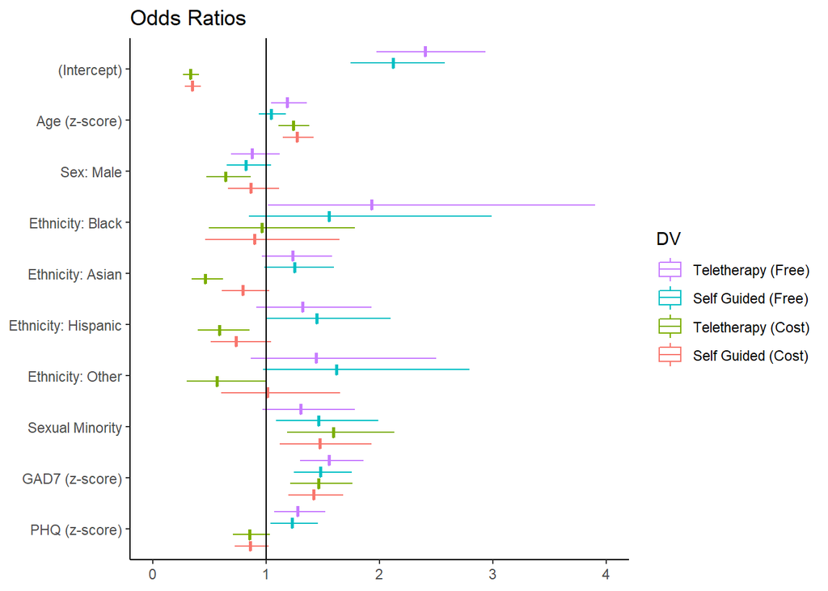

# Appendix

## Exploratory Logistic Regressions

Confidence intervals are not adjusted for multiple comparisons

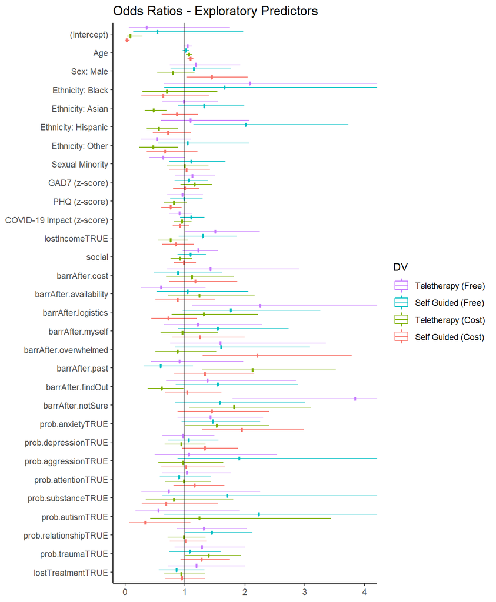

## Interest by Ethnicity

### Overall

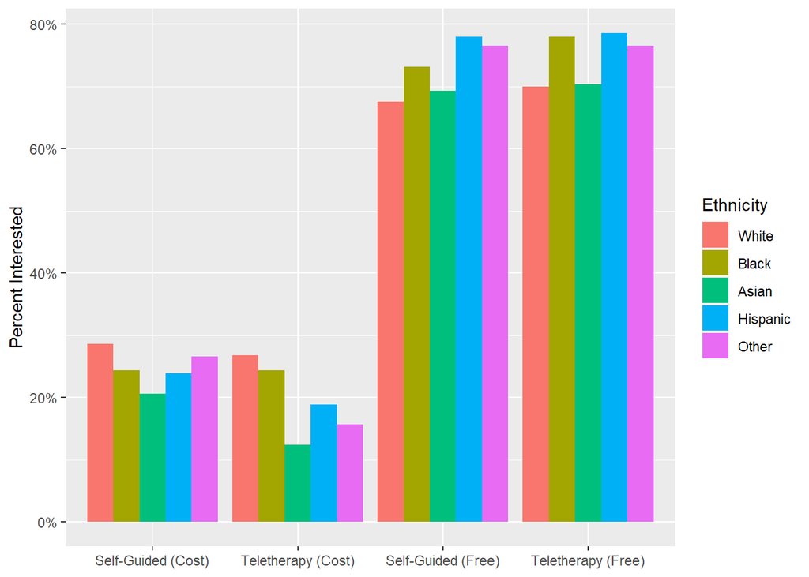

### Post-hoc Comparison: Self-Guided vs Teletherapy at Cost by Race

```
## [1] 1
## # A tibble: 2 x 3
##   teletherapy selfGuidedFALSE selfGuidedTRUE
##   <lgl>                 <int>          <int>
## 1 FALSE                   302             57
## 2 TRUE                     48             83
##
##  McNemar's Chi-squared test with continuity correction
##
## data:  temp$interest.teletherapy.cost and temp$interest.selfGuided.cost
## McNemar's chi-squared = 0.60952, df = 1, p-value = 0.435
##
## [1] 2
## # A tibble: 2 x 3
##   teletherapy selfGuidedFALSE selfGuidedTRUE
##   <lgl>                 <int>          <int>
## 1 FALSE                    27              4
## 2 TRUE                      4              6
##
##  McNemar's Chi-squared test
##
## data:  temp$interest.teletherapy.cost and temp$interest.selfGuided.cost
## McNemar's chi-squared = 0, df = 1, p-value = 1
##
## [1] 3
## # A tibble: 2 x 3
##   teletherapy selfGuidedFALSE selfGuidedTRUE
##   <lgl>                 <int>          <int>
## 1 FALSE                   355             57
## 2 TRUE                     18             40
##
##  McNemar's Chi-squared test with continuity correction
##
## data:  temp$interest.teletherapy.cost and temp$interest.selfGuided.cost
## McNemar's chi-squared = 19.253, df = 1, p-value = 1.145e-05
##
## [1] 4
## # A tibble: 2 x 3
##   teletherapy selfGuidedFALSE selfGuidedTRUE
##   <lgl>                 <int>          <int>
## 1 FALSE                   111             18
## 2 TRUE                     10             20
##
##  McNemar's Chi-squared test with continuity correction
##
## data:  temp$interest.teletherapy.cost and temp$interest.selfGuided.cost
## McNemar's chi-squared = 1.75, df = 1, p-value = 0.1859
##
## [1] 5
## # A tibble: 2 x 3
##   teletherapy selfGuidedFALSE selfGuidedTRUE
##   <lgl>                 <int>          <int>
## 1 FALSE                    45              9
## 2 TRUE                      2              8
##
##  McNemar's Chi-squared test with continuity correction
##
## data:  temp$interest.teletherapy.cost and temp$interest.selfGuided.cost
## McNemar's chi-squared = 3.2727, df = 1, p-value = 0.07044
```

## Preferences by Service Type

### Correlations Between Preferences

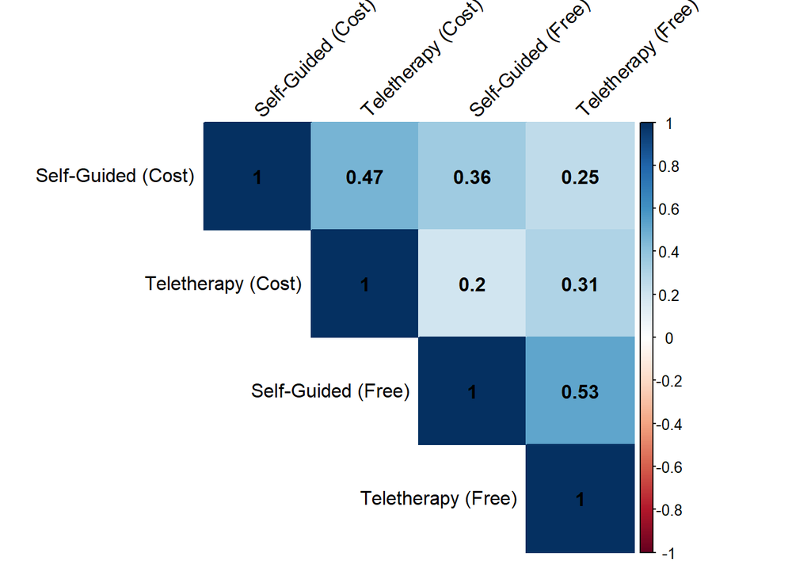

All correlations are significant at p < .01

### Participants by Interest in Each Service

| Self-Guided (Cost) | Teletherapy (Cost) | Self-Guided (Free) | Teletherapy (Free) | n | pct |
| --- | --- | --- | --- | --- | --- |
| Not Intersted | Not Intersted | Interested | Interested | 421 | 34% |
| Not Intersted | Not Intersted | Not Intersted | Not Intersted | 235 | 19% |
| Interested | Interested | Interested | Interested | 155 | 13% |
| Interested | Not Intersted | Interested | Interested | 118 | 10% |
| Not Intersted | Not Intersted | Not Intersted | Interested | 100 | 8% |
| Not Intersted | Not Intersted | Interested | Not Intersted | 84 | 7% |
| Not Intersted | Interested | Interested | Interested | 57 | 5% |
| Not Intersted | Interested | Not Intersted | Interested | 25 | 2% |
| Interested | Not Intersted | Interested | Not Intersted | 25 | 2% |
| Interested | Not Intersted | Not Intersted | Interested | 2 | 0% |
| Interested | Interested | Not Intersted | Interested | 2 | 0% |

### Participant Demographics by Interest

For the three largest groups identified in the table above: participants who were interested in all services, participants who weren’t interested in any of the services, and participants who were interested in only the free services.

| Variable | Respondent interested in… All Services | Respondent interested in… Free Services Only | Respondent interested in… No Services | Respondent interested in… Other |
| --- | --- | --- | --- | --- |
| n | 155.00 | 421.00 | 235.00 | 413.00 |
| prop | 0.13 | 0.34 | 0.19 | 0.34 |
| age | 21.87 | 20.51 | 20.62 | 20.57 |
| male | 0.25 | 0.28 | 0.37 | 0.23 |
| white | 0.54 | 0.31 | 0.43 | 0.42 |
| black | 0.04 | 0.04 | 0.03 | 0.02 |
| asian | 0.25 | 0.43 | 0.40 | 0.38 |
| hispanic | 0.13 | 0.15 | 0.09 | 0.13 |
| other | 0.05 | 0.06 | 0.04 | 0.05 |
| sexualMinority | 1.27 | 1.20 | 1.11 | 1.22 |
| GAD | 9.56 | 8.91 | 5.01 | 8.12 |
| PHQ | 10.81 | 11.28 | 6.57 | 10.30 |

## Missing Data

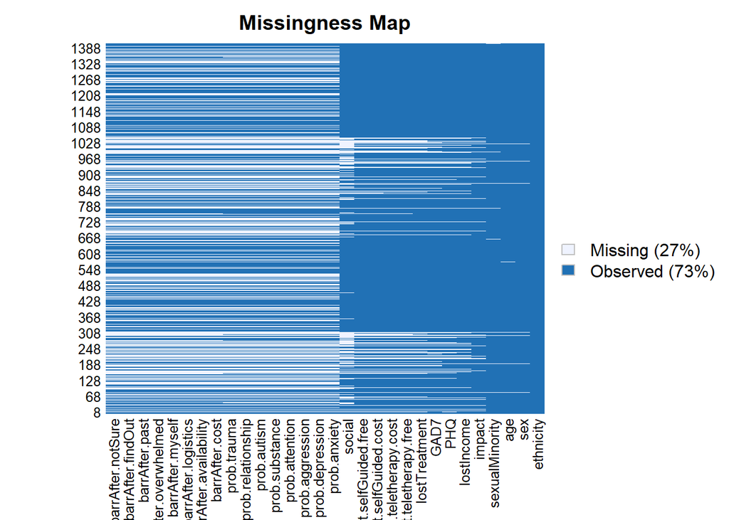